# PracticalMachineLearning

# APPENDIX:

## OTHER MODELS:

*Boosting Model*

```r
fit_boost <- train(classe ~ ., data = train, method = "gbm", trControl = control, verbose = FALSE)
pred_boost<-predict(fit_boost, newdata=cross)
conM_gbm <- confusionMatrix(pred_boost, cross$classe)
Acc2 <- conM_gbm$overall[1] # Gives accuracy
```

*Decision Tree*

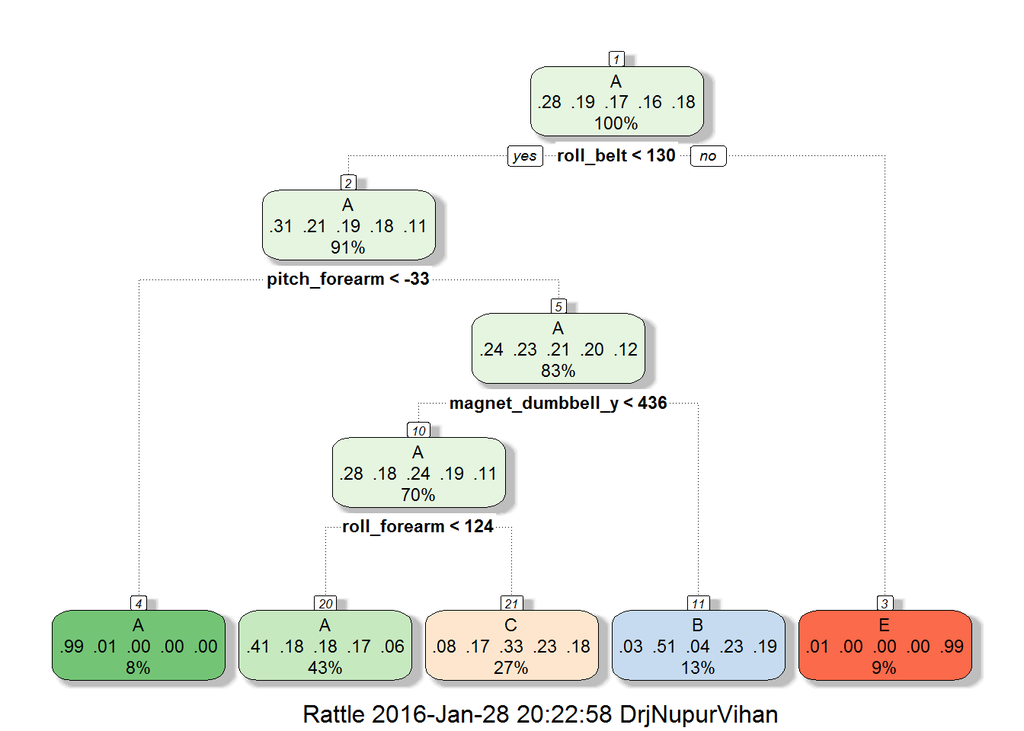

```r
fit_tree <- train(classe ~ ., data = train, method = "rpart")
pred_tree<-predict(fit_tree, newdata=cross)
conM_tree <- confusionMatrix(pred_tree, cross$classe)
Acc3 <- conM_tree$overall[1] # Gives accuracy
fancyRpartPlot(fit_tree$finalModel)
```

**Accuracy Tabulation**

| Model | Accuracy |
| --- | --- |
| R. Forest | 100 % |
| D. Tree | 50.0242483 % |
| Boosting | 97.3084384 % |

## OTHER CODE SNIPPETS:

**Failed gsub cleaning**  
The below method was used initially as a cleaning and data prep approach, however led to memory issues and hence was abandoned. The same approach could be tried on test data set for consistency.

```r
Training <- apply(Training, 2, function(x) gsub("#DIV/0!", NA, x))
Training <- apply(Training, 2, function(x) gsub("^$|^ $", NA, x))
Training <- as.data.frame(Training[, colSums(is.na(Training))==0])
```

## CITATION:

Velloso, E.; Bulling, A.; Gellersen, H.; Ugulino, W.; Fuks, H. [Qualitative Activity Recognition of Weight Lifting Exercises](http://groupware.les.inf.puc-rio.br/public/papers/2013.Velloso.QAR-WLE.pdf). Proceedings of 4th International Conference in Cooperation with SIGCHI (Augmented Human ’13) . Stuttgart, Germany: ACM SIGCHI, 2013.